# 4 questions for 46 students

Thanasit C.

2024-02-04

## 1. Summary

As I mentioned earlier, all statistical values show a clear result of no relationship. Some trend had shown up, but there are not statistical significant. Moreover,number of observations are too low, gather more data might be a good the way to go.

## 2. Note

Please find my datasets as I attached. And don’t forget to change folder path.

## 3. Libraries

```r
library(dplyr)
library(ggplot2)
library(ggpubr)
library(tidyverse)
library(forcats)
library(esquisse)
```

## 4. Import data

There are 9 csv files to import. I set a path and use [For] function to looping import. I assigned data name as [df1] to [df9].

```r
## Change dataset folder path
folderpath <- "/Users/sieng/Documents/Study/MS.Business Analytics/SPRING 2024/Business Anaytics/BA - Assignment/BA - Assignment1/BA - Assignment1 - Input Data/"
setwd(folderpath)

## Collect file name from folder and store in a new created list
filenamelist <- list.files(folderpath, pattern = "*.csv", full.names = TRUE)

## loop creating dataframe
for (i in 1:length(filenamelist)){
  assign(paste("df", i, sep = ""), read.csv(filenamelist[i]))
}
```

## 5. Data Manipulation

Before combine 9 dataframes into a single dataframe, there are some problem need to bi fixed such as number of columns, column name, data type.

### 5.1. Clean data for combining

Print out all column name. As you can see, the column names are different, number of column are different, and column arrangement are also different.  
There are 3 steps as shown below.

```r
## Checking column names by loop printing
for (i in 1:length(filenamelist)){
  dfname <- paste("df", i, sep = "")
  print(dfname)
  print(colnames(get(dfname)))
}
```

```
## [1] "df1"
## [1] "genre"  "exp"    "drinks" "food"
## [1] "df2"
## [1] "X..PERSON"  "GENRE"      "EXPERIENCE" "DRINKS"     "FOOD"
## [1] "df3"
## [1] "X"      "genre"  "exp"    "drinks" "food"
## [1] "df4"
## [1] "X"      "genre"  "exp"    "drinks" "food"
## [1] "df5"
## [1] "X"           "genre"       "drinks"      "experiences" "food"
## [1] "df6"
## [1] "S.No"              "Names"             "Movie.Genre"
## [4] "Work.exp.category" "Drinks"            "Food"
## [1] "df7"
## [1] "X"        "genre"    "Exprence" "drinks"   "food"
## [1] "df8"
## [1] "X"                        "Movie.genre"
## [3] "No..of.Drinks"            "experience.in.years"
## [5] "Amount.spent.on.food...."
## [1] "df9"
## [1] "X"          "Genre"      "Experience" "Drinks"     "Food"
```

First, select only the column needed form each dataframe.

```r
## Select needed column
df2 <- df2[,2:5]
df3 <- df3[,2:5]
df4 <- df4[,2:5]
df5 <- df5[,2:5]
df6 <- df6[,3:6]
df7 <- df7[,2:5]
df8 <- df8[,2:5]
df9 <- df9[,2:5]

## Loop printing results
for (i in 1:length(filenamelist)){
  dfname <- paste("df", i, sep = "")
  print(dfname)
  print(colnames(get(dfname)))
}
```

```
## [1] "df1"
## [1] "genre"  "exp"    "drinks" "food"
## [1] "df2"
## [1] "GENRE"      "EXPERIENCE" "DRINKS"     "FOOD"
## [1] "df3"
## [1] "genre"  "exp"    "drinks" "food"
## [1] "df4"
## [1] "genre"  "exp"    "drinks" "food"
## [1] "df5"
## [1] "genre"       "drinks"      "experiences" "food"
## [1] "df6"
## [1] "Movie.Genre"       "Work.exp.category" "Drinks"
## [4] "Food"
## [1] "df7"
## [1] "genre"    "Exprence" "drinks"   "food"
## [1] "df8"
## [1] "Movie.genre"              "No..of.Drinks"
## [3] "experience.in.years"      "Amount.spent.on.food...."
## [1] "df9"
## [1] "Genre"      "Experience" "Drinks"     "Food"
```

Then, rearrange column of dataframe [df5] and [df8] to be aligned with the other.

```r
## Column reordering
df5 <- df5[,c(1,3,2,4)]
df8 <- df8[,c(1,3,2,4)]

## Loop printing results
for (i in 1:length(filenamelist)){
  dfname <- paste("df", i, sep = "")
  print(dfname)
  print(colnames(get(dfname)))
}
```

```
## [1] "df1"
## [1] "genre"  "exp"    "drinks" "food"
## [1] "df2"
## [1] "GENRE"      "EXPERIENCE" "DRINKS"     "FOOD"
## [1] "df3"
## [1] "genre"  "exp"    "drinks" "food"
## [1] "df4"
## [1] "genre"  "exp"    "drinks" "food"
## [1] "df5"
## [1] "genre"       "experiences" "drinks"      "food"
## [1] "df6"
## [1] "Movie.Genre"       "Work.exp.category" "Drinks"
## [4] "Food"
## [1] "df7"
## [1] "genre"    "Exprence" "drinks"   "food"
## [1] "df8"
## [1] "Movie.genre"              "experience.in.years"
## [3] "No..of.Drinks"            "Amount.spent.on.food...."
## [1] "df9"
## [1] "Genre"      "Experience" "Drinks"     "Food"
```

Last step before combining, change column name to Genre, Experiences, Drinks, and Food respectively.

```r
## Change column names
for (i in 1:length(filenamelist)){
  dfname <- paste("df", i, sep = "")
  newcolname <- c("Genre", "Experiences", "Drinks", "Food")
  assign(dfname, `colnames<-`(get(dfname), newcolname))
  print(dfname)
  print(colnames(get(dfname)))
}
```

```
## [1] "df1"
## [1] "Genre"       "Experiences" "Drinks"      "Food"
## [1] "df2"
## [1] "Genre"       "Experiences" "Drinks"      "Food"
## [1] "df3"
## [1] "Genre"       "Experiences" "Drinks"      "Food"
## [1] "df4"
## [1] "Genre"       "Experiences" "Drinks"      "Food"
## [1] "df5"
## [1] "Genre"       "Experiences" "Drinks"      "Food"
## [1] "df6"
## [1] "Genre"       "Experiences" "Drinks"      "Food"
## [1] "df7"
## [1] "Genre"       "Experiences" "Drinks"      "Food"
## [1] "df8"
## [1] "Genre"       "Experiences" "Drinks"      "Food"
## [1] "df9"
## [1] "Genre"       "Experiences" "Drinks"      "Food"
```

### 5.2. Combining to form a single dataframe

After getting a correct column names and column structure then merge data by using [rbin] function.

```r
## Combine 9 manipulated dataframe
maindf <- df1
for (i in 2:length(filenamelist)){
  maindf <- rbind(maindf, get(paste("df", i, sep = "")))
}
maindf
```

```
##    Genre Experiences Drinks Food
## 1      O           L      2  200
## 2      H           L      1   70
## 3      C           L      1  245
## 4      A           L      1  245
## 5      A           L      2   90
## 6      A           L      2   45
## 7      A           L      4   40
## 8      C           M      3   15
## 9      A           M      2   50
## 10     A           M      2   50
## 11     A           H      6  100
## 12     A           L      4   32
## 13     C           M      3   22
## 14     A           L      2   25
```

[output cut: 32 more lines]

### 5.3. Correct data class (type)

Even if we get a complete 46 observations dataframe, data class are not correct as you can see by using [str] function.”Genre”, “Experiences”, and “Food” are [character] class which is incorrect. By the way, “Drinks” is [integer] class which is correct.  
Both “Genre” and “Experiences” are Category data however, there is a different between the two. “Genre” is a Nominal-Category data so its class should be a [factor] in the other hand, “Experiences” is an Ordinary-Category data so its class should be a [factor with ordered]. Since “Drinks” is an Numeric data which should be classed as [integer] or [numeric], so we do nothing. Lastly, “Food” is also a Numeric data so the correct class can be [numeric] or [integer] class.  
1) “Genre” should be a [factor].  
2) “Experiences” should be a [factor with ordered], H > M > L.  
3) “Drinks” is in a correct class as [integer].  
4) “Food” should be a [numeric] or [integer].

```r
str(maindf)
```

```
## 'data.frame':    46 obs. of  4 variables:
##  $ Genre      : chr  "O" "H" "C" "A" ...
##  $ Experiences: chr  "L" "L" "L" "L" ...
##  $ Drinks     : int  2 1 1 1 2 2 4 3 2 2 ...
##  $ Food       : chr  "200" "70" "245" "245" ...
```

After complete identifying data class, there few problems left before we can change data class.  
1) For “Genre”, there are [space] attached to data and there is an uppercase-lowercase issue. Remove [space] and convert all data in a form of uppercase then we can convert data class to [factor].  
2) For “Food”, there are [$] and [space] attached to data. Remove both of them then convert to [numeric] class.

```r
## Remove [space] and convert to uppercase from 'Genre' column, change data class to [factor]
maindf$Genre <- gsub(pattern = "\\s", "", maindf$Genre)
maindf$Genre <- as.factor(toupper(maindf$Genre))

## change 'Experiences' to [factor with ordered]
maindf$Experiences <- factor(maindf$Experiences, levels = c("L", "M", "H"), ordered = TRUE)

## Remove non-numeric then change to [numeric] class
maindf$Food <- as.numeric(gsub(pattern = "[^0-9.]", "",maindf$Food))
str(maindf)
```

```
## 'data.frame':    46 obs. of  4 variables:
##  $ Genre      : Factor w/ 4 levels "A","C","H","O": 4 3 2 1 1 1 1 2 1 1 ...
##  $ Experiences: Ord.factor w/ 3 levels "L"<"M"<"H": 1 1 1 1 1 1 1 2 2 2 ...
##  $ Drinks     : int  2 1 1 1 2 2 4 3 2 2 ...
##  $ Food       : num  200 70 245 245 90 45 40 15 50 50 ...
```

```r
maindf
```

```
##    Genre Experiences Drinks Food
## 1      O           L      2  200
## 2      H           L      1   70
## 3      C           L      1  245
## 4      A           L      1  245
## 5      A           L      2   90
## 6      A           L      2   45
## 7      A           L      4   40
## 8      C           M      3   15
## 9      A           M      2   50
## 10     A           M      2   50
## 11     A           H      6  100
## 12     A           L      4   32
## 13     C           M      3   22
## 14     A           L      2   25
```

[output cut: 32 more lines]

## 6. Analysis

After getting a nice and clean dataframe, shell we start our analysis?

### 6.1. Qualitative data

6.1.1. Descriptive statistics There are 2 qualitative data which are ‘Genre’ and ‘Experiences’.  
1) There are 46 person in the class, 21 persons or equivalent to 45.65% that love to watch ‘Action’ movies. ‘Horror’ movies are the least favorite genre according to student in the class.  
2) More than a half of student have low working experiences (56.52%).

```r
## 'Genre' table with percentage
print("Movie Genre")
summgenre <- summary(maindf$Genre) %>% as.data.frame()
colnames(summgenre)[1] <- "count"
summgenre$Percentage <- round(summgenre$count/sum(summgenre$count)*100, digits = 0)
print(summgenre)

## 'Experiences' table with percentage
print("Working Experiences")
summexp <- summary(maindf$Experiences) %>% as.data.frame()
colnames(summexp)[1] <- "count"
summexp$Percentage <- round(summexp$count/sum(summexp$count)*100, digits = 0)
print(summexp)
```

```
## [1] "Movie Genre"
##   count Percentage
## A    21         46
## C    14         30
## H     5         11
## O     6         13
## [1] "Working Experiences"
##   count Percentage
## L    26         57
## M    10         22
## H    10         22
```

6.1.2. Data visualization

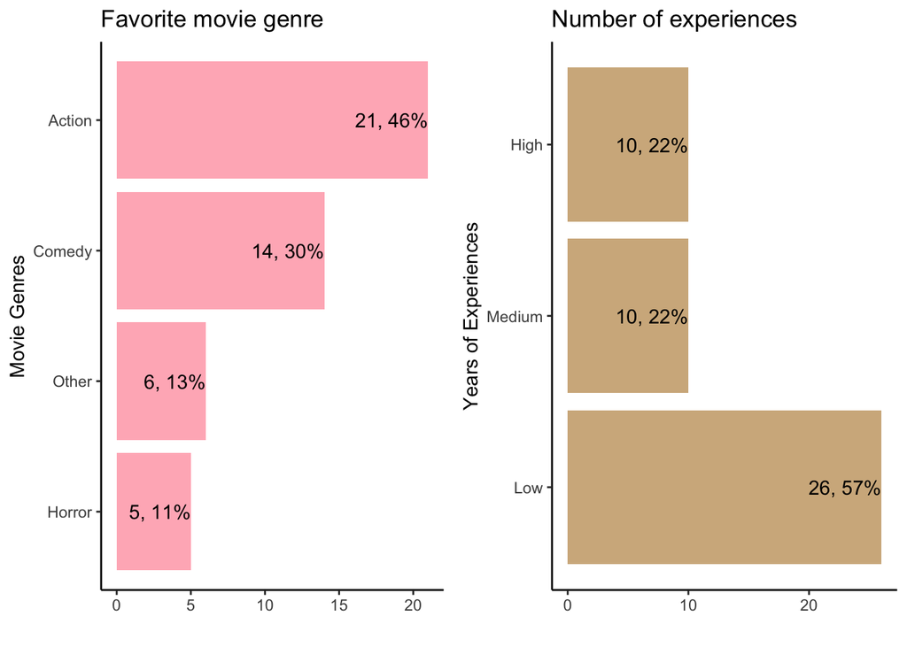

```r
## Create Bar chart for 'Genre'
bargenre <- maindf %>% ggplot(mapping = aes(y = fct_rev(fct_infreq(Genre)))) +
                         geom_bar(fill = "lightpink") +
                         geom_text(mapping = aes(y = Genre, label = paste((..count..), paste(round((..count..)/sum(..count..)*100, digits = 0), "%", sep = ""), sep = ", ")),
                                   stat = "count",
                                   hjust = +1) +
                         labs(title = "Favorite movie genre") +
                         ylab(label = "Movie Genres") +
                         xlab(label = "") +
                         scale_y_discrete(breaks=c("A", "C", "H", "O"),
                                          labels=c("Action", "Comedy", "Horror", "Other")) +
                         theme_classic()

## Create Bar chart for 'Food'
barexp <- maindf %>% ggplot(mapping = aes(y = Experiences)) +
                        geom_bar(fill = "tan") +
                        geom_text(mapping = aes(y = Experiences, label = paste((..count..), paste(round((..count..)/sum(..count..)*100, digits = 0), "%", sep = ""), sep = ", ")),
                                   stat = "count",
                                   hjust = +1) +
                        labs(title = "Number of experiences") +
                        ylab(label = "Years of Experiences") +
                        xlab(label = "") +
                        scale_y_discrete(breaks=c("H","M","L"),
                                         labels=c("High", "Medium", "Low")) +
                        theme_classic()

## Combine chart
fullbar <- ggarrange(bargenre, barexp, ncol = 2, nrow = 1)
fullbar
```

### 6.2. Quantitative data

6.2.1. Descriptive statistics There 2 quantitative data which are ‘Drinks’ and ‘Food’. There are lot of statistic functions for data explanation process such as ‘mean’, ‘standard deviation’, ‘variance’, ‘range’, ‘max’, ‘min’, ‘qualtile’, ‘quantile’, ‘correlation’, and ect.  
1) 5-number summary for ‘Drinks’.  
2) 5-number summary for ‘Food’.  
3) ‘mean’, ‘standard deviation’, ‘range’ of ‘Drinks’ variable.  
4) ‘mean’, ‘standard deviation’, ‘range’ of ‘Food’ variable.  
5) correlation between ‘Drinks’ and ‘Food’.

```r
## 5-number summary for 'Drinks'
fivedrinks <- fivenum(maindf$Drinks) %>% as.data.frame()
colnames(fivedrinks)[1] <- "Drinks"
fivedrinks$Statistics <- c("min", "q1", "median", "q3", "max")
fivesummary <- fivedrinks[,c(2,1)]

## 5-number summary for ' Food'
fivefood <- fivenum(maindf$Food) %>% as.data.frame()
colnames(fivefood)[1] <- "Food"

## Create 5-number summary table
fivesummary$Food <- fivefood$Food
print(fivesummary)
```

```
##   Statistics Drinks  Food
## 1        min    0.0   0.0
## 2         q1    1.0  20.0
## 3     median    1.5  37.5
## 4         q3    2.0 100.0
## 5        max    6.0 432.0
```

```r
## Calculate [Mean]
meandrinks <- round(mean(maindf$Drinks), digits = 2)
meanfood <- round(mean(maindf$Food), digits = 2)
tablemean <- t(c("mean",meandrinks , meanfood)) %>% as.data.frame()
colnames(tablemean) <- c("Statistics", "Drinks", "Food")

## Calculate [Standard deviation]
stddevdrinks <- round(sd(maindf$Drinks), digits = 2)
stddevfood <- round(sd(maindf$Food), digits = 2)
tablestddev <- t(c("StdDev", stddevdrinks, stddevfood)) %>% as.data.frame()
colnames(tablestddev) <- c("Statistics", "Drinks", "Food")

## Calculate [Mode]
getmode <- function(m) {
   uniqv <- unique(m)
   uniqv[which.max(tabulate(match(m, uniqv)))]
}
m <- maindf$Drinks %>% as.list()
modedrinks <- getmode(m)
m <- maindf$Food %>% as.list()
modefood <- getmode(m)
tablemode <- t(c("mode", modedrinks, modefood)) %>% as.data.frame()
colnames(tablemode) <- c("Statistics", "Drinks", "Food")

## Calculate [Range]
rangedrinks <- max(maindf$Drinks) - min(maindf$Drinks)
rangefood <- max(maindf$Food) - min(maindf$Food)
tablerange <- t(c("range", rangedrinks, rangefood)) %>% as.data.frame()
colnames(tablerange) <- c("Statistics", "Drinks", "Food")

## Calculate [Correlation]
corrdrinksfood <- round(cor(maindf$Drinks, maindf$Food), digits = 2)
tablecorr <- t(c("correlation", corrdrinksfood, corrdrinksfood)) %>% as.data.frame()
colnames(tablecorr) <- c("Statistics", "Drinks", "Food")

## Combine all statistics into a single table
tablestats <- rbind(fivesummary, tablemean, tablestddev, tablemode, tablerange, tablecorr)
tablestats$Drinks <- as.numeric(tablestats$Drinks)
tablestats$Food <- as.numeric(tablestats$Food)
#str(tablestats)
print(tablestats)
```

```
##     Statistics Drinks   Food
## 1          min   0.00   0.00
## 2           q1   1.00  20.00
## 3       median   1.50  37.50
## 4           q3   2.00 100.00
## 5          max   6.00 432.00
## 6         mean   1.72  80.65
## 7       StdDev   1.56 102.61
## 8         mode   2.00  20.00
## 9        range   6.00 432.00
## 10 correlation  -0.13  -0.13
```

6.2.2. Data visualization

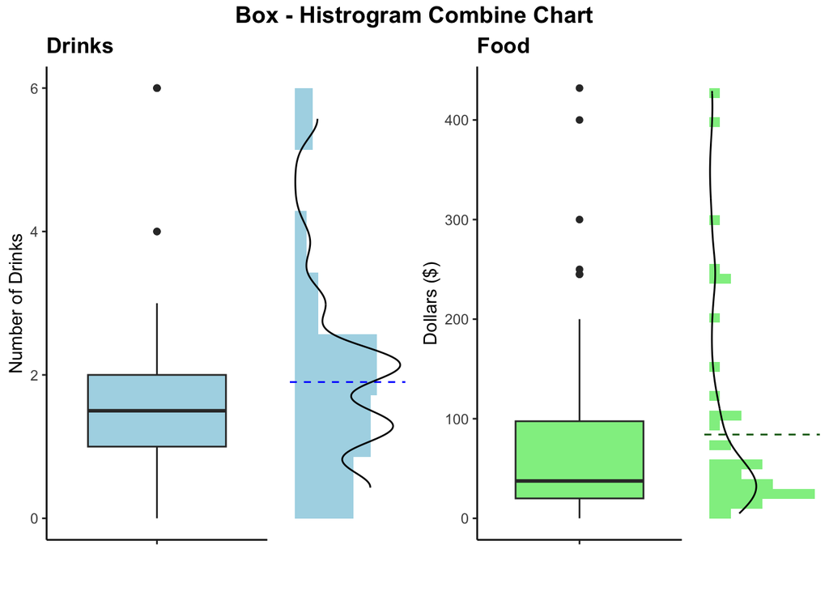

```r
##### Plot 'Drinks' ###############
## Create box plot
boxdrinks <- maindf %>% ggplot(mapping = aes(x = "", y = Drinks))+
                          geom_boxplot(mapping = aes(stat ="identify"),
                                       fill = "lightblue") +
                          labs(title = "Drinks") +
                          ylab(label = "Number of Drinks") +
                          xlab(label = "") +
                          theme_classic() +
                          theme(legend.position = "top",
                                plot.title = element_text(face = "bold"))

## Create histogram
hisdrinks <- maindf %>% ggplot(mapping = aes(x = Drinks)) +
                          geom_histogram(mapping = aes(y = ..density..),
                                         fill = "lightblue",
                                         binwidth = 1) +
                          geom_vline(mapping = aes(xintercept = mean(Drinks)),
                                     color = "blue",
                                     linetype = "dashed") +
                          clean_theme() +
                          theme(panel.background = element_blank(),
                                panel.grid = element_blank()) +
                          labs(x = "NULL", y = "NULL") +
                          coord_flip() +
                          stat_density(geom = "line")

## Combine box plot and histrogram
drinksboxhis <- ggarrange(boxdrinks, hisdrinks,
                          ncol = 2, nrow = 1,
                          widths = c(2,1), heights = c(1,1),
                          common.legend = TRUE,
                          align = "h")

##### Plot 'Food' ###############
## Create box plot
boxfood <- maindf %>% ggplot(mapping = aes(x = "", y = Food)) +
                        geom_boxplot(mapping = aes(stat ="identify"),
                                     fill = "lightgreen") +
                        labs(title = "Food") +
                        ylab(label = "Dollars ($)") +
                        xlab(label = "") +
                        theme_classic() +
                        theme(legend.position = "top",
                              plot.title = element_text(face = "bold"))

## Create histogram
hisfood <- maindf %>% ggplot(mapping = aes(x = Food)) +
                        geom_histogram(mapping = aes(y = ..density..),
                                       fill = "lightgreen",
                                       binwidth = 10) +
                        geom_vline(mapping = aes(xintercept = mean(Food)),
                                   color = "darkgreen",
                                   linetype = "dashed") +
                        clean_theme() +
                        theme(panel.background = element_blank(),
                              panel.grid = element_blank()) +
                        labs(x = "NULL", y = "NULL") +
                        coord_flip() +
                        stat_density(geom = "line")

## Combine box plot and histrogram
foodboxhis <- ggarrange(boxfood, hisfood,
                        ncol = 2, nrow = 1,
                        widths = c(2,1), heights = c(1,1),
                        common.legend = TRUE,
                        align = "h")

##### Combine 'Drinks' and 'Food' ###############
boxhisplot <- ggarrange(drinksboxhis, foodboxhis, ncol = 2, nrow = 1) %>% annotate_figure(top = text_grob("Box - Histrogram Combine Chart", color = "black", face = "bold", size = 14))
boxhisplot
```

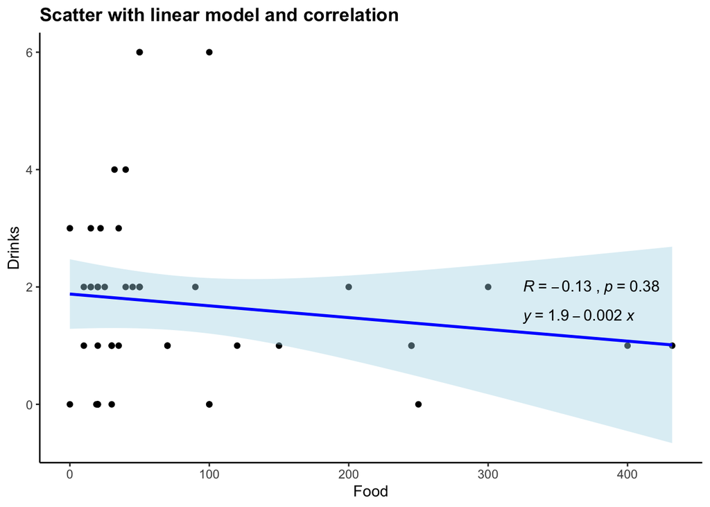

```r
##### Correlation ###############
## Create scatter plot between 'Drinks' and 'Food', adding trend line, adding linear model equation, adding R-square, and adding correlation (r).
corrplot <- maindf %>% ggplot(mapping = aes(x = Food, y = Drinks)) +
                         geom_point() +
                         geom_smooth(method = "lm",
                                     color = "blue",
                                     fill = "lightblue") +
                         labs(title = "Scatter with linear model and correlation") +
                         stat_cor(mapping = aes(label = paste(..r.label.., ..p.label.., sep = "~','~")),
                                  label.x = 325,
                                  label.y = 2) +
                         stat_regline_equation(label.x = 325, label.y = 1.5) +
                         theme_classic() +
                         theme(plot.title = element_text(face = "bold"))
corrplot
```

### 6.3. Quantitative data by qualitative

Plotting a Box plot of quantitative data against qualitative data.  
1) According to the student in the class, person who love watching comedy movies tend to drink more.  
2) Student who have high working experiences tend to drink than the other.  
3) Student who like action movies probably spend more on food.  
4) Align with number of drinks in a day, the person who have high working experiences tend to spend more on food than the other.  
5) Investigate correlation between 2 quantitative data by ‘Genre’ and ‘Experiences’.

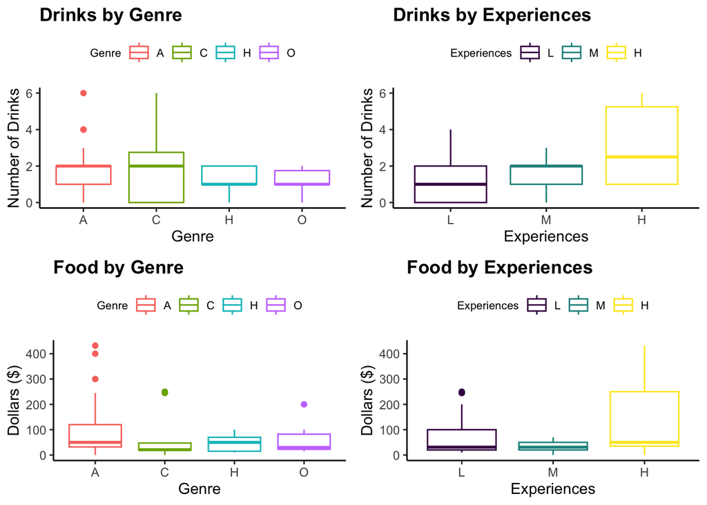

```r
##### 'Drinks' by 'Genre' and 'Experiences' ###############
## Create 'Drinks' box plot by 'Genre'
boxdrinksgenre <- maindf %>% ggplot(mapping = aes(x = Genre, y = Drinks)) +
                                geom_boxplot(mapping = aes(color = Genre)) +
                                labs(title = "Drinks by Genre") +
                                ylab(label = "Number of Drinks") +
                                theme_classic() +
                                theme(legend.position = "top",
                                      plot.title = element_text(face = "bold"),
                                      legend.text = element_text(size = 8),
                                      legend.title = element_text(size = 8))

## Create 'Drinks' box plot by 'Experiences'
boxdrinksexp <- maindf %>% ggplot(mapping = aes(x = Experiences, y = Drinks)) +
                             geom_boxplot(mapping = aes(color = Experiences)) +
                             labs(title = "Drinks by Experiences") +
                             ylab(label = "Number of Drinks") +
                             theme_classic() +
                             theme(legend.position = "top",
                                   plot.title = element_text(face = "bold"),
                                   legend.text = element_text(size = 8),
                                   legend.title = element_text(size = 8))

## Combine two box plot
ggdrinks <- ggarrange(boxdrinksgenre, boxdrinksexp, ncol = 2, nrow = 1)

##### 'Food' by 'Genre' and 'Experiences' ###############
## Create 'Food' box plot by 'Genre'
boxfoodgenre <- maindf %>% ggplot(mapping = aes(x = Genre, y = Food))+
                             geom_boxplot(mapping = aes(color = Genre)) +
                             labs(title = "Food by Genre") +
                             ylab(label = "Dollars ($)") +
                             theme_classic() +
                             theme(legend.position = "top",
                                   plot.title = element_text(face = "bold"),
                                   legend.text = element_text(size = 8),
                                   legend.title = element_text(size = 8))

## Create 'Food' box plot by 'Experiences'
boxfoodexp <- maindf %>% ggplot(mapping = aes(x = Experiences, y = Food))+
                           geom_boxplot(mapping = aes(color = Experiences)) +
                           labs(title = "Food by Experiences") +
                           ylab(label = "Dollars ($)") +
                           theme_classic() +
                           theme(legend.position = "top",
                                 plot.title = element_text(face = "bold"),
                                 legend.text = element_text(size = 8),
                                 legend.title = element_text(size = 8))

## Combine two box plot
ggfood <- ggarrange(boxfoodgenre, boxfoodexp, ncol = 2, nrow = 1)

##### Combine 'Drinks' and 'Food' ###############
fullboxplot <- ggarrange(ggdrinks, ggfood, ncol = 1, nrow = 2)
fullboxplot
```

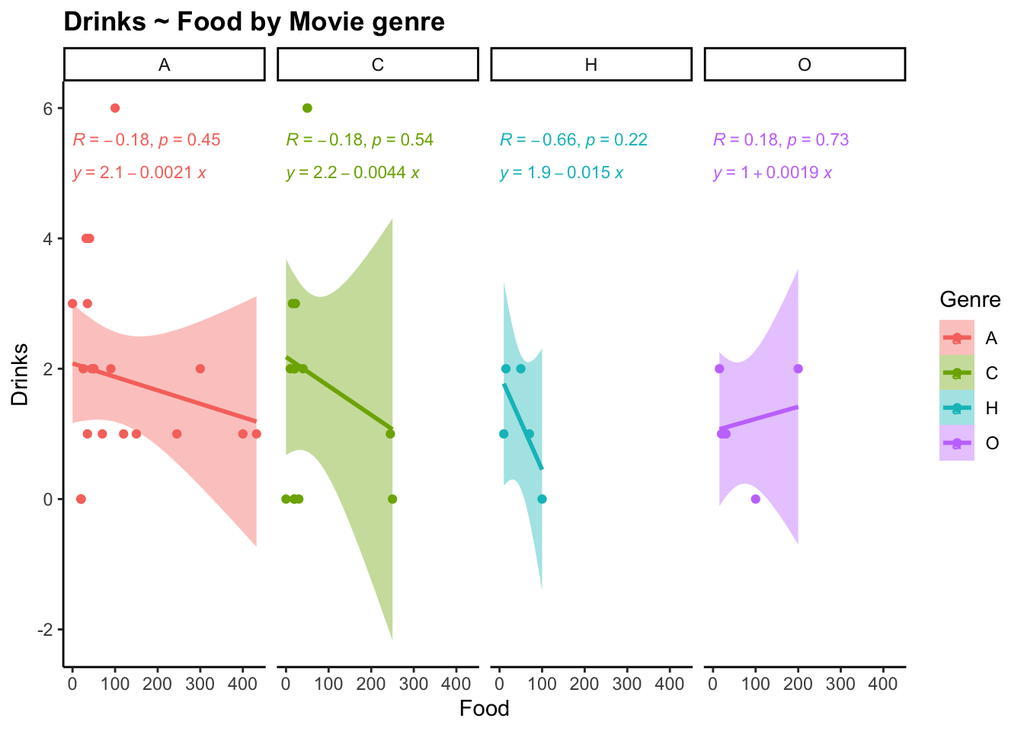

```r
##### Correlation ###############
## Create a scatter plot by 'Genre' and adding trend line and correlation
scatbygenre <- maindf %>% ggplot(mapping = aes(x=Food, y=Drinks)) +
                            geom_point(mapping = aes(color = Genre)) +
                            geom_smooth(mapping = aes(color = Genre, fill = Genre), method = "lm") +
                            labs(title = "Drinks ~ Food by Movie genre") +
                            stat_cor(mapping = aes(lable = paste(..r.label.., ..p.label.., sep = "~','~"), color = Genre),
                                     label.x = 0, label.y = 5.5,
                                     size = 3) +
                            stat_regline_equation(mapping = aes(color = Genre),
                                                  label.x = 0, label.y = 5,
                                                  size = 3) +
                            theme_classic() +
                            theme(plot.title = element_text(face = "bold")) +
                            facet_grid(.~Genre)
scatbygenre
```

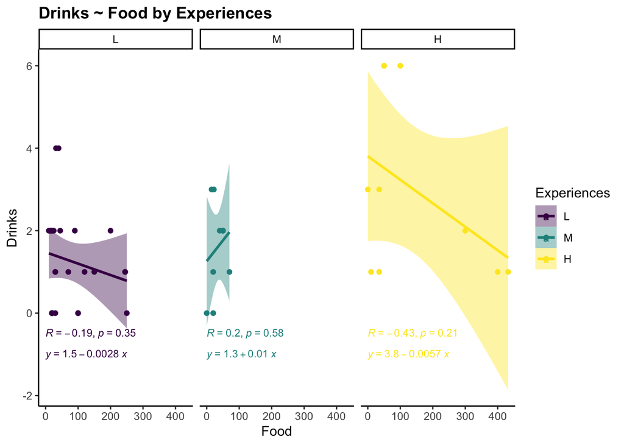

```r
## Create a scatter plot by 'Experiences' and adding trend line and correlation
scatbyexp <- maindf %>% ggplot(mapping = aes(x=Food, y=Drinks)) +
                          geom_point(mapping = aes(color = Experiences)) +
                          geom_smooth(mapping = aes(color = Experiences, fill = Experiences), method = "lm") +
                          labs(title = "Drinks ~ Food by Experiences") +
                          stat_cor(mapping = aes(lable = paste(..r.label.., ..p.label.., sep = "~','~"), color = Experiences),
                                   label.x = 0, label.y = -0.5,
                                   size = 3) +
                          stat_regline_equation(mapping = aes(color = Experiences),
                                                 label.x = 0, label.y = -1,
                                                 size = 3) +
                          theme_classic() +
                          theme(plot.title = element_text(face = "bold")) +
                          facet_grid(.~Experiences)
scatbyexp
```